# 📚 Fundamentos de visualização

## 📊 Anatomia de um Gráfico

Um gráfico possui várias partes:

- **Figure**: toda a imagem do gráfico
- **Axes**: os eixos do gráfico (pode haver mais de um)
- **Axis**: o eixo X e o eixo Y individuais
- **Ticks**: marcações dos eixos
- **Labels**: rótulos dos eixos
- **Title**: título do gráfico
- **Legend**: legenda de elementos traçados

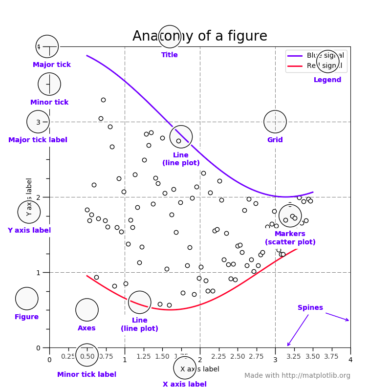

Essa imagem mostra tudo que pode ser alterado dentro de um gráfico. Então tudo que está circulado com texto em azul pode ser modificado pelo usuário.

## ✍️ Gramática da configuração de um Gráfico

Podemos pensar na configuração de um gráfico em programação como uma gramática visual:

- **Dados** → `x`, `y`
- **Estética** → `cor`, `formato`, `linha`, `marcador`
- **Geometria** → `plot()`, `scatter()`, `bar()`
- **Escala** → linear, log, etc.
- **Facetas** → `subplot`
- **Tema** → `style`, grid, fonte, etc.

## 🧠 Bibliotecas para DataViz em Python

A visualização de dados é uma etapa essencial no processo de análise, pois traduz números em narrativas visuais compreensíveis. O ecossistema Python oferece uma variedade robusta de bibliotecas para visualização, cada uma com propósitos, níveis de abstração e públicos diferentes.

| Biblioteca | Nível | Baseada em | Interativa | Estática | Facilidade | Performance | Suporte a Web | Casos de Uso Ideais |
| --- | --- | --- | --- | --- | --- | --- | --- | --- |
| **Matplotlib** | Baixo nível | Nativo Python | ❌ | ✅ | Média | Alta | ❌ | Gráficos básicos, controle fino, publicações científicas |
| **Seaborn** | Médio nível | Matplotlib | ❌ | ✅ | Alta | Alta | ❌ | Estatísticas, EDA, dados estruturados (DataFrames) |
| **Plotly** | Alto nível | JavaScript | ✅ | ✅ | Alta | Média | ✅ | Dashboards interativos, web apps, relatórios dinâmicos |
| **Bokeh** | Alto nível | JavaScript | ✅ | ✅ | Média | Média | ✅ | Web apps, dashboards, interações ricas |
| **Altair** | Alto nível | Vega-Lite | ✅ | ✅ | Alta | Média | ✅ | Visualização declarativa, EDA rápido, ciência de dados |
| **ggplot (plotnine)** | Médio nível | Matplotlib | ❌ | ✅ | Alta | Média | ❌ | Visualização tipo ggplot2 (R), análises estatísticas |
| **Holoviews** | Alto nível | Bokeh/Matplotlib | ✅ | ✅ | Alta | Alta | ✅ | Grandes volumes de dados, pipelines declarativos |
| **Pygal** | Alto nível | SVG | ✅ | ✅ | Alta | Baixa | ✅ | Gráficos SVG elegantes para web |
| **Dash** | Aplicações | Plotly | ✅ | ✅ | Alta | Média | ✅ | Construção de dashboards com backend Python |
| **Panel** | Aplicações | Bokeh/Holoviews | ✅ | ✅ | Alta | Alta | ✅ | Apps com widgets, dashboards complexos |

Não existe uma única melhor biblioteca — existe a melhor para o seu contexto. Entender o ecossistema permite fazer escolhas inteligentes e comunicar dados com clareza, precisão e impacto visual.

| Contexto | Bibliotecas Recomendadas |
| --- | --- |
| Publicações científicas | `Matplotlib`, `Seaborn` |
| Análise exploratória (EDA) | `Seaborn`, `Altair`, `Plotly` |
| Dashboards interativos | `Plotly`, `Dash`, `Panel` |
| Visualização em web estática | `Pygal`, `Altair`, `Plotly` |
| Grandes volumes de dados | `Holoviews`, `Datashader` |
| Familiaridade com ggplot2 do R | `plotnine` |
| Aplicações analíticas completas | `Dash`, `Panel`, `Streamlit`* |